# PROJECT-1-FINAL-REPORT

2022-10-28

# Measuring the relationship between the S&P 500 and unemployment/disposable income

## Md Abyan Wahed, Maw5683

## Introduction

Datasets: S&P 500: Yahoo Finance, quantmod library

Disposable Income per Capita: https://fred.stlouisfed.org/series/A229RC0

Unemployment Level by Thousands: https://data.bls.gov/cgi-bin/surveymost

```r
## Loading libraries
library(tidyverse)
library(dplyr)
library(lubridate)
library(ggplot2)
library(TTR)
library(quantmod)
library(readxl)
library(readr)
library(knitr)
library(data.table)
```

## Tidying

Here, I grab the S&P 500 data from Yahoo Finance with a function from ‘quantmod’.

```r
gspc <- getSymbols('^GSPC', src = "yahoo", auto.assign = FALSE)
df_gspc <- as.data.frame(gspc) ## Converting into data frame
```

Then, I set the row names as the column headers and created a dataset that only showed the first day of every month since 2012, as this is when the dates for my other datasets begin. I had to recode the third of every January to the first as Yahoo Finance didn’t record the prices on the first of every January.

```r
setDT(df_gspc, keep.rownames = "Date")

head(df_gspc)
```

```
##          Date GSPC.Open GSPC.High GSPC.Low GSPC.Close GSPC.Volume GSPC.Adjusted
## 1: 2007-01-03   1418.03   1429.42  1407.86    1416.60  3429160000       1416.60
## 2: 2007-01-04   1416.60   1421.84  1408.43    1418.34  3004460000       1418.34
## 3: 2007-01-05   1418.34   1418.34  1405.75    1409.71  2919400000       1409.71
## 4: 2007-01-08   1409.26   1414.98  1403.97    1412.84  2763340000       1412.84
## 5: 2007-01-09   1412.84   1415.61  1405.42    1412.11  3038380000       1412.11
## 6: 2007-01-10   1408.70   1415.99  1405.32    1414.85  2764660000       1414.85
```

```r
final_gspc <- df_gspc %>%
  mutate(Date = recode(Date, "2012-01-03" = "2012-01-01",
                             "2013-01-03" = "2013-01-01",
                             "2014-01-03" = "2014-01-01",
                             "2015-01-03" = "2015-01-01",
                             "2016-01-03" = "2016-01-01",
                             "2017-01-03" = "2017-01-01",
                             "2018-01-03" = "2018-01-01",
                             "2019-01-03" = "2019-01-01",
                             "2020-01-03" = "2020-01-01",
                             "2021-01-03" = "2021-01-01",
                             "2022-01-03" = "2022-01-01")) %>%
  mutate(Date = as.Date(Date)) %>%
  filter(day(Date) == "1") %>%
  filter(year(Date) >= 2012)
```

Here, I import the unemployment data from excel file I downloaded and remove uninformative rows as well as setting the the first row as the column headers.

```r
SeriesReport_20221029190345_1dbae5 <- read_excel("~/Desktop/SeriesReport-20221029190345_1dbae5.xlsx")
unemployment <- SeriesReport_20221029190345_1dbae5
unemployment_1 <- unemployment[11:22, ] ## Keep informative rows
names(unemployment_1) <- unemployment_1[1, ] ## Take first row as column headers
unemployment_2 <- unemployment_1[-1, ] ## Delete first row
head(unemployment_2)
```

```
## # A tibble: 6 × 13
##   Year  Jan   Feb   Mar   Apr   May   Jun   Jul   Aug   Sep   Oct   Nov   Dec
##   <chr> <chr> <chr> <chr> <chr> <chr> <chr> <chr> <chr> <chr> <chr> <chr> <chr>
## 1 2012  12797 12813 12713 12646 12660 12692 12656 12471 12115 12124 12005 12298
## 2 2013  12471 11950 11689 11760 11654 11751 11335 11279 11270 11136 10787 10404
## 3 2014  10202 10349 10380 9702  9859  9460  9608  9599  9262  8990  9090  8717
## 4 2015  8885  8599  8515  8550  8834  8247  8167  7992  7907  7922  8000  7907
## 5 2016  7627  7702  7961  8067  7652  7744  7641  7784  7953  7811  7553  7521
## 6 2017  7468  7379  7073  7089  7000  6873  6892  7082  6854  6700  6774  6632
```

I use pivot_longer to tidy the dataset into columns of Year, Month, and value. I recode the months to their numerical values so that they can be merged easily with the Year.

```r
unemployment_3 <- unemployment_2 %>%
  pivot_longer(cols = Jan:Dec, names_to = "Month", values_to = "value")
head(unemployment_3)
```

```
## # A tibble: 6 × 3
##   Year  Month value
##   <chr> <chr> <chr>
## 1 2012  Jan   12797
## 2 2012  Feb   12813
## 3 2012  Mar   12713
## 4 2012  Apr   12646
## 5 2012  May   12660
## 6 2012  Jun   12692
```

```r
unemployment_4 <- mutate(unemployment_3, Month = recode(unemployment_3$Month, Jan = "1",
       Feb = "2",
       Mar = "3",
       Apr = "4",
       May = "5",
       Jun = "6",
       Jul = "7",
       Aug = "8",
       Sep = "9",
       Oct = "10",
       Nov = "11",
       Dec = "12"))

head(unemployment_4)
```

```
## # A tibble: 6 × 3
##   Year  Month value
##   <chr> <chr> <chr>
## 1 2012  1     12797
## 2 2012  2     12813
## 3 2012  3     12713
## 4 2012  4     12646
## 5 2012  5     12660
## 6 2012  6     12692
```

Instead of having just month and year, I added a column of repeating 1’s and merged the Year, Month, and Day columns separated by a dash so I could easily use the as.Date function. This would allow me to join with my S&P 500 dataset.

```r
Day <- c(rep(1,132)) ## Create a vector of 1's with the length of my dataset

unemployment_5 <- unemployment_4 %>%
  cbind(Day) %>% ## Attach the column of 1's to my dataset
  select(Year, Month, Day, value) %>%
  mutate(Date = paste(Year, Month, Day, sep = "-")) %>%
  mutate(Date = as.Date(Date)) %>%
  select(Date, value, -Year, -Month, -Day) ## Remove repetitive variables

head(unemployment_5)
```

```
##         Date value
## 1 2012-01-01 12797
## 2 2012-02-01 12813
## 3 2012-03-01 12713
## 4 2012-04-01 12646
## 5 2012-05-01 12660
## 6 2012-06-01 12692
```

I import the disposable income data from a csv file and convert the “Date” variable from characters to a Date.

```r
A229RC0 <- read_csv("~/Desktop/A229RC0.csv")
disposable <- A229RC0
disposable_2 <- disposable %>%
  mutate(Date = as.Date(DATE)) %>%
  select(-DATE) %>%
  rename(DispIncome = A229RC0)

head(disposable_2)
```

```
## # A tibble: 6 × 2
##   DispIncome Date
##        <dbl> <date>
## 1       1999 1959-01-01
## 2       2005 1959-02-01
## 3       2015 1959-03-01
## 4       2029 1959-04-01
## 5       2039 1959-05-01
## 6       2049 1959-06-01
```

## Joining/Merging

I used left_join on the last unemployment dataset with the S&P 500 data by date and removed any missing values, which matched only dates that existed in the unemployment dataset as the S&P dataset was bigger. I repeated this process with the resulting dataset and the disposable income to combine all 3 of my datasets. Lastly, I created a new column called “OHLC” which took the average the open, close, low, and high daily prices of the S&P 500 and represented it as a kable.

```r
sp_vs_un <-
  left_join(unemployment_5, final_gspc, by = "Date") %>%
  filter(!is.na(GSPC.Open)) ## Remove missing values

sp_vs_un_2 <- sp_vs_un %>%
  mutate(value = as.numeric(value)) ## Convert value from character to numeric
head(sp_vs_un_2)
```

```
##         Date value GSPC.Open GSPC.High GSPC.Low GSPC.Close GSPC.Volume
## 1 2012-01-01 12797   1258.86   1284.62  1258.86    1277.06  3943710000
## 2 2012-02-01 12813   1312.45   1330.52  1312.45    1324.09  4504360000
## 3 2012-03-01 12713   1365.90   1376.17  1365.90    1374.09  3919240000
## 4 2012-05-01 12660   1397.86   1415.32  1395.73    1405.82  3807950000
## 5 2012-06-01 12692   1309.87   1309.87  1277.25    1278.04  4669350000
## 6 2012-08-01 12471   1379.32   1385.03  1373.35    1375.32  4440920000
##   GSPC.Adjusted
## 1       1277.06
## 2       1324.09
## 3       1374.09
## 4       1405.82
## 5       1278.04
## 6       1375.32
```

```r
join_table <-
  left_join(sp_vs_un_2, disposable_2, by = "Date")
join_table
```

```
##          Date value GSPC.Open GSPC.High GSPC.Low GSPC.Close GSPC.Volume
## 1  2012-01-01 12797   1258.86   1284.62  1258.86    1277.06  3943710000
## 2  2012-02-01 12813   1312.45   1330.52  1312.45    1324.09  4504360000
## 3  2012-03-01 12713   1365.90   1376.17  1365.90    1374.09  3919240000
## 4  2012-05-01 12660   1397.86   1415.32  1395.73    1405.82  3807950000
## 5  2012-06-01 12692   1309.87   1309.87  1277.25    1278.04  4669350000
## 6  2012-08-01 12471   1379.32   1385.03  1373.35    1375.32  4440920000
## 7  2012-10-01 12124   1440.90   1457.14  1440.90    1444.49  3505080000
## 8  2012-11-01 12005   1412.20   1428.35  1412.20    1427.59  3929890000
## 9  2013-01-01 12471   1462.42   1465.47  1455.53    1459.37  3829730000
## 10 2013-02-01 11950   1498.11   1514.41  1498.11    1513.17  3836320000
## 11 2013-03-01 11689   1514.68   1519.99  1501.48    1518.20  3695610000
## 12 2013-04-01 11760   1569.18   1570.57  1558.47    1562.17  2753110000
## 13 2013-05-01 11654   1597.55   1597.55  1581.28    1582.70  3530320000
## 14 2013-07-01 11335   1609.78   1626.61  1609.78    1614.96  3104690000
```

[output cut: 169 more lines]

```r
final_table <-
  join_table %>%
  mutate(OHLC = (GSPC.Open + GSPC.Low + GSPC.High + GSPC.Close)/4) ## Calculating average of the four prices in dataset

kable(head(final_table, n = 20))  ## Display first 20 rows as kable
```

| Date | value | GSPC.Open | GSPC.High | GSPC.Low | GSPC.Close | GSPC.Volume | GSPC.Adjusted | DispIncome | OHLC |
| --- | --- | --- | --- | --- | --- | --- | --- | --- | --- |
| 2012-01-01 | 12797 | 1258.86 | 1284.62 | 1258.86 | 1277.06 | 3943710000 | 1277.06 | 38986 | 1269.850 |
| 2012-02-01 | 12813 | 1312.45 | 1330.52 | 1312.45 | 1324.09 | 4504360000 | 1324.09 | 39285 | 1319.877 |
| 2012-03-01 | 12713 | 1365.90 | 1376.17 | 1365.90 | 1374.09 | 3919240000 | 1374.09 | 39485 | 1370.515 |
| 2012-05-01 | 12660 | 1397.86 | 1415.32 | 1395.73 | 1405.82 | 3807950000 | 1405.82 | 39633 | 1403.682 |
| 2012-06-01 | 12692 | 1309.87 | 1309.87 | 1277.25 | 1278.04 | 4669350000 | 1278.04 | 39563 | 1293.758 |
| 2012-08-01 | 12471 | 1379.32 | 1385.03 | 1373.35 | 1375.32 | 4440920000 | 1375.32 | 39277 | 1378.255 |
| 2012-10-01 | 12124 | 1440.90 | 1457.14 | 1440.90 | 1444.49 | 3505080000 | 1444.49 | 40011 | 1445.858 |
| 2012-11-01 | 12005 | 1412.20 | 1428.35 | 1412.20 | 1427.59 | 3929890000 | 1427.59 | 40483 | 1420.085 |
| 2013-01-01 | 12471 | 1462.42 | 1465.47 | 1455.53 | 1459.37 | 3829730000 | 1459.37 | 39094 | 1460.698 |
| 2013-02-01 | 11950 | 1498.11 | 1514.41 | 1498.11 | 1513.17 | 3836320000 | 1513.17 | 39109 | 1505.950 |
| 2013-03-01 | 11689 | 1514.68 | 1519.99 | 1501.48 | 1518.20 | 3695610000 | 1518.20 | 39156 | 1513.587 |
| 2013-04-01 | 11760 | 1569.18 | 1570.57 | 1558.47 | 1562.17 | 2753110000 | 1562.17 | 39221 | 1565.098 |
| 2013-05-01 | 11654 | 1597.55 | 1597.55 | 1581.28 | 1582.70 | 3530320000 | 1582.70 | 39413 | 1589.770 |
| 2013-07-01 | 11335 | 1609.78 | 1626.61 | 1609.78 | 1614.96 | 3104690000 | 1614.96 | 39468 | 1615.283 |
| 2013-08-01 | 11279 | 1689.42 | 1707.85 | 1689.42 | 1706.87 | 3775170000 | 1706.87 | 39591 | 1698.390 |
| 2013-10-01 | 11136 | 1682.41 | 1696.55 | 1682.07 | 1695.00 | 3238690000 | 1695.00 | 39665 | 1689.008 |
| 2013-11-01 | 10787 | 1758.70 | 1765.67 | 1752.70 | 1761.64 | 3686290000 | 1761.64 | 39801 | 1759.677 |
| 2014-01-01 | 10202 | 1833.21 | 1838.24 | 1829.13 | 1831.37 | 2774270000 | 1831.37 | 40186 | 1832.987 |
| 2014-04-01 | 9702 | 1873.96 | 1885.84 | 1873.96 | 1885.52 | 3336190000 | 1885.52 | 40896 | 1879.820 |
| 2014-05-01 | 9859 | 1884.39 | 1888.59 | 1878.04 | 1883.68 | 3416740000 | 1883.68 | 41089 | 1883.675 |

## Data Wrangling

For my first categorical statistic, I create a column in the dataset that says “Decrease” if the closing price is less than the opening price and “Increase” if the closing price is greater than the opening price. I then calculate the proportion of “Increase” and “Decrease” in the dataset. For my second categorical variable, I create another column that says “Over” if the volume for the day is greater than the average volume and “Under” for when the volume is less than the average volume. Similar to the first statistic, I calculate the proportion of “Over” and “Under” for the dataset.

```r
## Categorical Statistics

mean(final_table$GSPC.Volume) ## Determine the mean volume to use in following statement
```

```
## [1] 3858156154
```

```r
final_table$OpenToClose <-
  ifelse(final_table$GSPC.Open > final_table$GSPC.Close, "Decrease",
        ifelse(final_table$GSPC.Open < final_table$GSPC.Close, "Increase", "No Change"))

final_table %>%
  group_by(OpenToClose) %>%
  count() %>%
  summarize(prop = n/nrow(final_table))
```

```
## # A tibble: 2 × 2
##   OpenToClose  prop
##   <chr>       <dbl>
## 1 Decrease    0.407
## 2 Increase    0.593
```

```r
final_table$VolOverAvg <-
  ifelse(final_table$GSPC.Volume > 3858156154, "Over",
         ifelse(final_table$GSPC.Volume < 3858156154, "Under", "Same"))

final_table %>%
  group_by(VolOverAvg) %>%
  count() %>%
  summarize(prop = n/nrow(final_table))
```

```
## # A tibble: 2 × 2
##   VolOverAvg  prop
##   <chr>      <dbl>
## 1 Over       0.407
## 2 Under      0.593
```

**Results: The daily price for the S&P 500 decreased around 40.66% of the time and increased around 59.34% of the time. Shockingly, these numbers are exactly the same for the volume statistic as the volume is over the average around 40.66% of the time and under the average 59.34% of the time. I checked and these were not the exact same rows.**

For my first numerical statistic, I calculate the proportion of unemployment values over 10000 to see what percentage of the time there were more than 10 million people unemployed. Then, I compute the standard deviation of the OHLC price by year. Afterwards, I calculate the correlation between the OHLC and variables including the unemployment levels, the amount of disposable income, and the volume of the S&P 500. Next, I obtain the net change from the the OHLC of the first entry in the dataset to the last entry in the dataset. Lastly, I produce a table that takes the mean volume of each month across the years to determine if there are any seasonal trends in the data.

```r
## Numerical statistics

## What's the proportion of unemployment values above 10,000?
final_table %>%
  filter(value >= 10000) %>%
  count() %>%
  summarize(prop = n / nrow(final_table))
```

```
##        prop
## 1 0.2747253
```

```r
## What's the standard deviation of the OHLC by year?
final_table %>%
  group_by(year(Date)) %>%
  summarize(sd = sd(OHLC))
```

```
## # A tibble: 11 × 2
##    `year(Date)`    sd
##           <int> <dbl>
##  1         2012  62.6
##  2         2013 100.
##  3         2014  74.1
##  4         2015  79.3
##  5         2016  91.4
##  6         2017 125.
##  7         2018  90.4
##  8         2019 181.
##  9         2020 377.
## 10         2021 310.
## 11         2022 333.
```

```r
## What's the correlation between unemployment levels and OHLC price?
final_table %>%
  select(-Date) %>%
  summarize(cor = cor(x = value, y = OHLC))
```

```
##          cor
## 1 -0.3498632
```

```r
## What's the correlation between disposable income and OHLC price?
final_table %>%
  select(-Date) %>%
  summarize(cor = cor(x = DispIncome, y = OHLC))
```

```
##         cor
## 1 0.9180031
```

```r
## What's the correlation between volume and OHLC price?
final_table %>%
  select(-Date) %>%
  summarize(cor = cor(x = GSPC.Volume, y = OHLC))
```

```
##          cor
## 1 0.02301345
```

```r
## What's the net change of the S&P 500 since 2012?
final_table %>%
  summarize(netchange = OHLC[91] - OHLC[1])
```

```
##   netchange
## 1  2674.515
```

```r
## What's the mean volume of the S&P 500 by month since 2012?
monthly_volume <- final_table %>%
  group_by(month(Date)) %>%
  summarize(meanVol = mean(GSPC.Volume)) %>%
  rename(Month = "month(Date)")
monthly_volume
```

```
## # A tibble: 12 × 2
##    Month    meanVol
##    <int>      <dbl>
##  1     1 3489530000
##  2     2 4183357500
##  3     3 4375871250
##  4     4 3851343750
##  5     5 3661562500
##  6     6 3961197500
##  7     7 3472662500
##  8     8 3846606250
##  9     9 3569035000
## 10    10 3632212500
## 11    11 3932020000
## 12    12 4393185000
```

**Results: There were over 10 million people unemployed in the US for 27.47% of the entries, and the data seems to spread far apart. Unemployment levels and the OHLC have a weak negative correlation. Disposable income and the OHLC have a strong positive correlation. The volume and the OHLC have almost no correlation. The net change of the S&P 500 from 2012 to 2022 is around 2,700.**

## Data Visualization

First, I model the relationship between OHLC and disposable income.

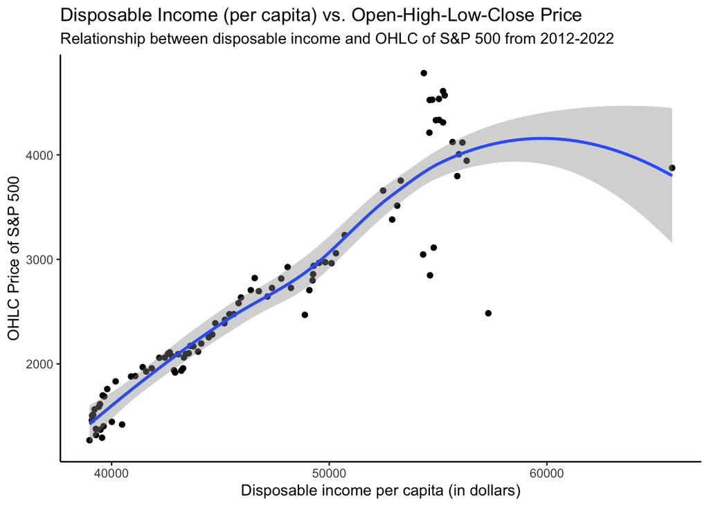

```r
final_table %>%
  ggplot(aes(x = DispIncome, y = OHLC)) +
  geom_point() +
  geom_smooth() +
  scale_x_continuous() +
  scale_y_continuous() +
  ggtitle("Disposable Income (per capita) vs. Open-High-Low-Close Price",
          subtitle = ("Relationship between disposable income and OHLC of S&P 500 from 2012-2022")) +
  xlab("Disposable income per capita (in dollars)") +
  ylab("OHLC Price of S&P 500") +
  theme_classic()
```

**Results: The plot clearly depicts a strong positive relationship between diposable income and the OHLC price of the S&P 500. This means that as disposable income grows, OHLC price tends to increase as well, and when disposable income decreases, the OHLC price tends to decrease as well. Basically, OHLC price and disposable income tend to move in the same direction. This suggests that disposable income per capita has a great impact on the OHLC price of the S&P 500.**

Then, I model the relationship between unemployment levels and the OHLC price of the S&P 500.

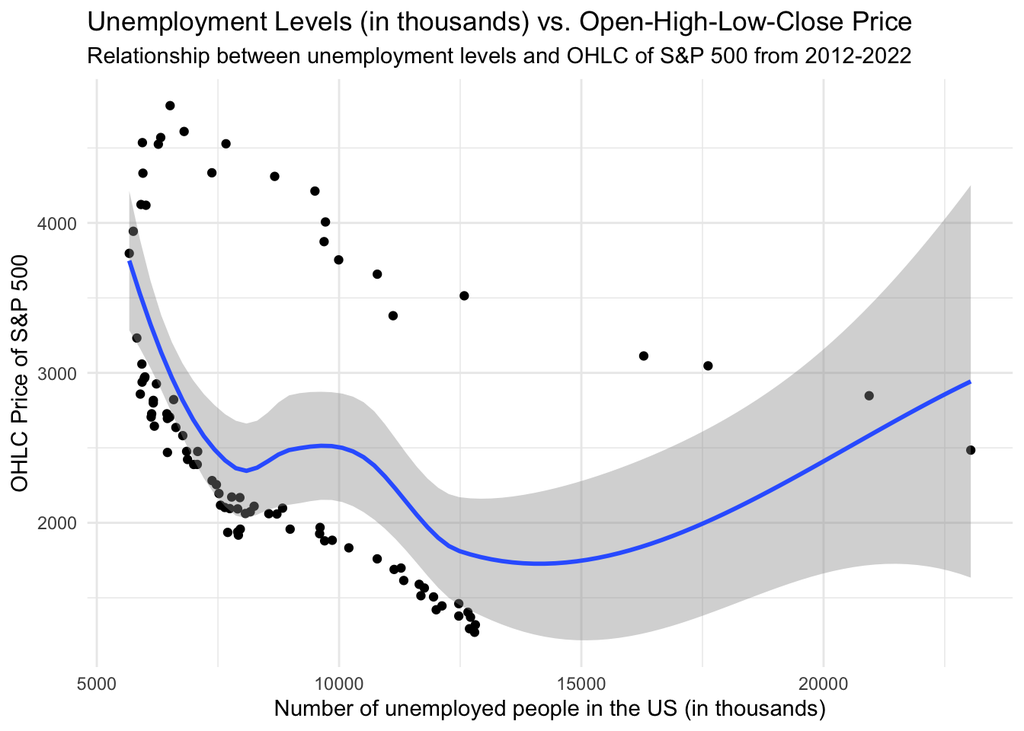

```r
arrange(final_table, value) %>%
  ggplot(aes(x = value, y = OHLC)) +
  geom_point() +
  geom_smooth() +
  scale_x_continuous() +
  scale_y_continuous() +
  ggtitle("Unemployment Levels (in thousands) vs. Open-High-Low-Close Price",
          subtitle = ("Relationship between unemployment levels and OHLC of S&P 500 from 2012-2022")) +
  xlab("Number of unemployed people in the US (in thousands)") +
  ylab("OHLC Price of S&P 500") +
  theme_minimal()
```

Next, I model the price changes of the S&P 5000 since 2012.

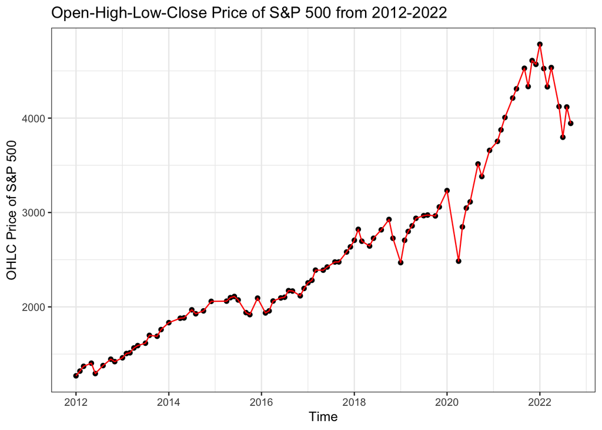

```r
arrange(final_table, value) %>%
  ggplot(aes(x = Date, y = OHLC)) +
  geom_point() +
  geom_line(color = "red") +
  scale_x_date() +
  scale_y_continuous() +
  ggtitle("Open-High-Low-Close Price of S&P 500 from 2012-2022") +
  xlab("Time") +
  ylab("OHLC Price of S&P 500") +
  theme_bw()
```

**Results: The obvious trend here is that the OHLC price of the S&P 500 seems to consistently grow despite a couple of minor fluctuations, which is the main reason investors choose this index fund for safe growth. The rate of growth seems to have increased by some extent in recent years. Also, the biggest observable drop in the OHLC price seems to have occured during 2020, which was during the Coronavirus pandemic. This is logical as the US experienced a major recession during the pandemic.**

Lastly, I create a bar chart of the mean volume of the S&P 500 by month.

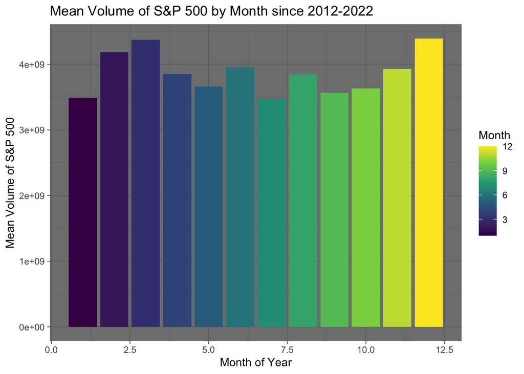

```r
monthly_volume %>%
  ggplot(aes(x = Month, y = meanVol, fill = Month)) +
  geom_bar(stat = "identity") +
  scale_x_continuous() +
  scale_y_continuous() +
  ggtitle("Mean Volume of S&P 500 by Month since 2012-2022") +
  xlab("Month of Year") +
  ylab("Mean Volume of S&P 500") +
  theme_dark() +
  scale_fill_viridis_c()
```

**Results: There are no major distinctions between months as I would have hoped, but it seems that March and December have the highest mean volumes. On the other hand, January and July seem to have the lowest volumes on average. This suggests that the number of shares traded is higher in March and December, which means that trading activity is more frequent during these two months.**